# Project: No Show Appointments Data Analysis

- Introduction
- Data Wrangling
- Exploratory Data Analysis
- Conclusions

## Introduction

### Dataset Description

Its dataset collects information from [100,000] medical appointments in Brazil and focuses on whether or not patients show up for their appointments.

- ‘ScheduledDay’ tells us on what day the patient set up their appointment.
- ‘Neighborhood’ indicates the location of the hospital.
- ‘Scholarship’ indicates whether or not the patient is enrolled in Brasilian welfare program Bolsa Família.
- Be careful about the encoding of the last column: it says ‘No’ if the patient showed up to their appointment, and ‘Yes’ if they did not show up.

```python
# import  the libraries that you will use
import numpy as np
import pandas as pd
import matplotlib.pyplot as plt
import seaborn as sns
%matplotlib inline
```

```python
# Upgrade pandas to use dataframe.explode() function.
!pip install --upgrade pandas==0.25.0
```

## Data Wrangling

```python
# Load your data and print out a few lines. Perform operations to inspect data
#   types and look for instances of missing or possibly errant data.
df = pd.read_csv('noshowappointments-kagglev2-may-2016.csv')
df.head()
```

|  | PatientId | AppointmentID | Gender | ScheduledDay | AppointmentDay | Age | Neighbourhood | Scholarship | Hipertension | Diabetes | Alcoholism | Handcap | SMS_received | No-show |
| --- | --- | --- | --- | --- | --- | --- | --- | --- | --- | --- | --- | --- | --- | --- |
| 0 | 2.987250e+13 | 5642903 | F | 2016-04-29T18:38:08Z | 2016-04-29T00:00:00Z | 62 | JARDIM DA PENHA | 0 | 1 | 0 | 0 | 0 | 0 | No |
| 1 | 5.589978e+14 | 5642503 | M | 2016-04-29T16:08:27Z | 2016-04-29T00:00:00Z | 56 | JARDIM DA PENHA | 0 | 0 | 0 | 0 | 0 | 0 | No |
| 2 | 4.262962e+12 | 5642549 | F | 2016-04-29T16:19:04Z | 2016-04-29T00:00:00Z | 62 | MATA DA PRAIA | 0 | 0 | 0 | 0 | 0 | 0 | No |
| 3 | 8.679512e+11 | 5642828 | F | 2016-04-29T17:29:31Z | 2016-04-29T00:00:00Z | 8 | PONTAL DE CAMBURI | 0 | 0 | 0 | 0 | 0 | 0 | No |
| 4 | 8.841186e+12 | 5642494 | F | 2016-04-29T16:07:23Z | 2016-04-29T00:00:00Z | 56 | JARDIM DA PENHA | 0 | 1 | 1 | 0 | 0 | 0 | No |

```python
# See the shape of the data (rows and columns)
df.shape
```

```
(110527, 14)
```

```python
# Information about the data
df.describe()
```

|  | PatientId | AppointmentID | Age | Scholarship | Hipertension | Diabetes | Alcoholism | Handcap | SMS_received |
| --- | --- | --- | --- | --- | --- | --- | --- | --- | --- |
| count | 1.105270e+05 | 1.105270e+05 | 110527.000000 | 110527.000000 | 110527.000000 | 110527.000000 | 110527.000000 | 110527.000000 | 110527.000000 |
| mean | 1.474963e+14 | 5.675305e+06 | 37.088874 | 0.098266 | 0.197246 | 0.071865 | 0.030400 | 0.022248 | 0.321026 |
| std | 2.560949e+14 | 7.129575e+04 | 23.110205 | 0.297675 | 0.397921 | 0.258265 | 0.171686 | 0.161543 | 0.466873 |
| min | 3.921784e+04 | 5.030230e+06 | -1.000000 | 0.000000 | 0.000000 | 0.000000 | 0.000000 | 0.000000 | 0.000000 |
| 25% | 4.172614e+12 | 5.640286e+06 | 18.000000 | 0.000000 | 0.000000 | 0.000000 | 0.000000 | 0.000000 | 0.000000 |
| 50% | 3.173184e+13 | 5.680573e+06 | 37.000000 | 0.000000 | 0.000000 | 0.000000 | 0.000000 | 0.000000 | 0.000000 |
| 75% | 9.439172e+13 | 5.725524e+06 | 55.000000 | 0.000000 | 0.000000 | 0.000000 | 0.000000 | 0.000000 | 1.000000 |
| max | 9.999816e+14 | 5.790484e+06 | 115.000000 | 1.000000 | 1.000000 | 1.000000 | 1.000000 | 4.000000 | 1.000000 |

```python
# Information about the data
df.info()
```

```
<class 'pandas.core.frame.DataFrame'>
RangeIndex: 110527 entries, 0 to 110526
Data columns (total 14 columns):
PatientId         110527 non-null float64
AppointmentID     110527 non-null int64
Gender            110527 non-null object
ScheduledDay      110527 non-null object
AppointmentDay    110527 non-null object
Age               110527 non-null int64
Neighbourhood     110527 non-null object
Scholarship       110527 non-null int64
Hipertension      110527 non-null int64
Diabetes          110527 non-null int64
Alcoholism        110527 non-null int64
Handcap           110527 non-null int64
SMS_received      110527 non-null int64
No-show           110527 non-null object
dtypes: float64(1), int64(8), object(5)
memory usage: 11.8+ MB
```

The data is complete

### Data Cleaning

```python
# Drop unused data
df.drop(['PatientId', 'AppointmentID', 'ScheduledDay', 'AppointmentDay' ], axis=1, inplace=True)
df.head(1)
```

|  | Gender | Age | Neighbourhood | Scholarship | Hipertension | Diabetes | Alcoholism | Handcap | SMS_received | No-show |
| --- | --- | --- | --- | --- | --- | --- | --- | --- | --- | --- |
| 0 | F | 62 | JARDIM DA PENHA | 0 | 1 | 0 | 0 | 0 | 0 | No |

```python
# spelling corrected (Hipertension)
df.rename(columns={'Hipertension': 'Hypertension'}, inplace=True)
df.head(1)
```

|  | Gender | Age | Neighbourhood | Scholarship | Hypertension | Diabetes | Alcoholism | Handcap | SMS_received | No-show |
| --- | --- | --- | --- | --- | --- | --- | --- | --- | --- | --- |
| 0 | F | 62 | JARDIM DA PENHA | 0 | 1 | 0 | 0 | 0 | 0 | No |

```python
# Rename No-show to (No_show)
df.rename(columns={'No-show':'No_show'}, inplace=True)
df.head(1)
```

|  | Gender | Age | Neighbourhood | Scholarship | Hypertension | Diabetes | Alcoholism | Handcap | SMS_received | No_show |
| --- | --- | --- | --- | --- | --- | --- | --- | --- | --- | --- |
| 0 | F | 62 | JARDIM DA PENHA | 0 | 1 | 0 | 0 | 0 | 0 | No |

```python
df.head()
```

|  | Gender | Age | Neighbourhood | Scholarship | Hypertension | Diabetes | Alcoholism | Handcap | SMS_received | No_show |
| --- | --- | --- | --- | --- | --- | --- | --- | --- | --- | --- |
| 0 | F | 62 | JARDIM DA PENHA | 0 | 1 | 0 | 0 | 0 | 0 | No |
| 1 | M | 56 | JARDIM DA PENHA | 0 | 0 | 0 | 0 | 0 | 0 | No |
| 2 | F | 62 | MATA DA PRAIA | 0 | 0 | 0 | 0 | 0 | 0 | No |
| 3 | F | 8 | PONTAL DE CAMBURI | 0 | 0 | 0 | 0 | 0 | 0 | No |
| 4 | F | 56 | JARDIM DA PENHA | 0 | 1 | 1 | 0 | 0 | 0 | No |

## Exploratory Data Analysis

### Look at the data

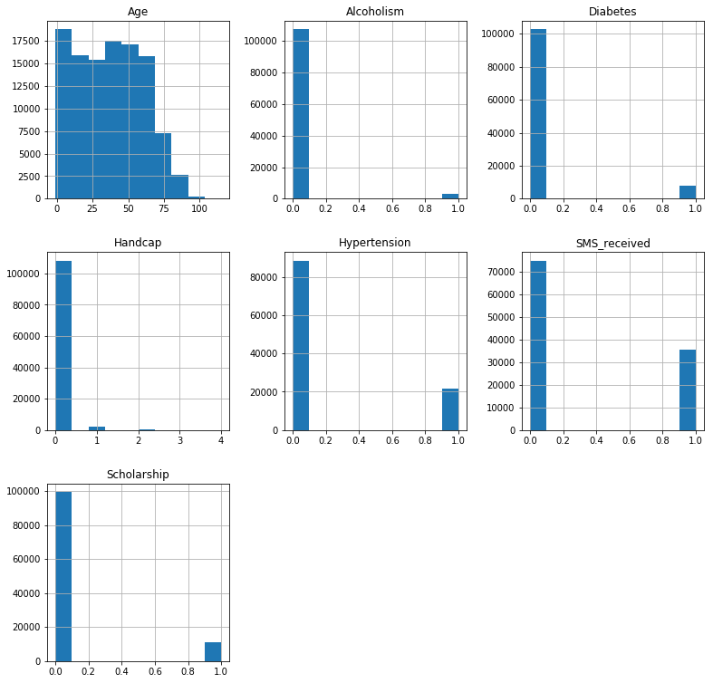

```python
# Data overview
df.hist(figsize=(13,13));
```

- Most patients do not suffer from Alcoholism
- Most patients do not suffer from Diabetes
- Most patients do not suffer fromHandcap
- Most patients do not suffer from hypertension, which is 20,000
- Who received the messages and attended half of those who did not receive
- Those who received sms half of those who did not receive

```python
# Assign names
SHOW=df.No_show== 'No'
NO_SHOW=df.No_show== 'Yes'
```

```python
# the number of people who went
df[SHOW].count()
```

```
Gender           88208
Age              88208
Neighbourhood    88208
Scholarship      88208
Hypertension     88208
Diabetes         88208
Alcoholism       88208
Handcap          88208
SMS_received     88208
No_show          88208
dtype: int64
```

```python
# The number of people who have not gone
df[NO_SHOW].count()
```

```
Gender           22319
Age              22319
Neighbourhood    22319
Scholarship      22319
Hypertension     22319
Diabetes         22319
Alcoholism       22319
Handcap          22319
SMS_received     22319
No_show          22319
dtype: int64
```

- We notice that the number of people who attended (88208) is greater than the number of people who were not counted (22319).

### Comparison of those who attended and did not attend

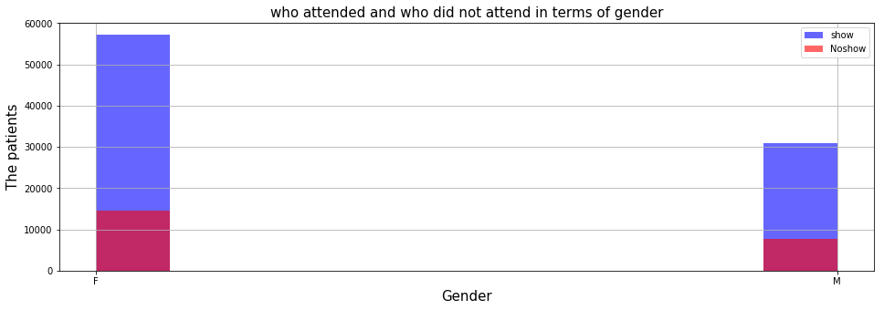

```python
# Does gender affect the attendance rate
plt.figure(figsize=[16, 5])
df.Gender[SHOW].hist(alpha=0.6, color='blue', label='show')
df.Gender[NO_SHOW].hist(alpha=0.6, color='red', label='Noshow');
plt.title('who attended and who did not attend in terms of gender', size=15)
plt.xlabel('Gender',size=15)
plt.ylabel('The patients', size=15,)
plt.legend();
```

```python
# Attendance rate
print(df.Gender[SHOW].value_counts())
```

```
F    57246
M    30962
Name: Gender, dtype: int64
```

```python
# Non attendance rate
print(df.Gender[NO_SHOW].value_counts())
```

```
F    14594
M     7725
Name: Gender, dtype: int64
```

## AGE

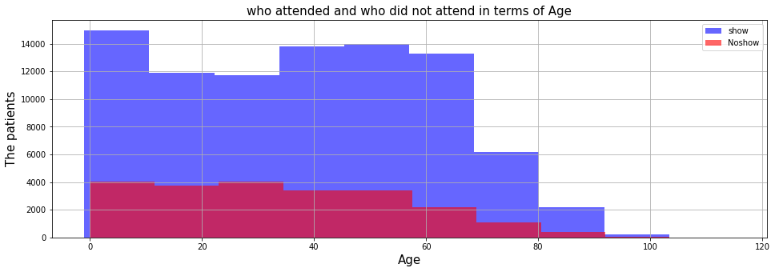

```python
# Does age affect attendance rate?
plt.figure(figsize=[16, 5])
df.Age[SHOW].hist(alpha=0.6, color='blue', label='show')
df.Age[NO_SHOW].hist(alpha=0.6, color='RED', label='Noshow');
plt.title('who attended and who did not attend in terms of Age', size=15)
plt.xlabel('Age',size=15)
plt.ylabel('The patients', size=15,)
plt.legend();
```

```python
# Attendance rate
print(df.Age[SHOW].value_counts().sum())
```

```
88208
```

```python
# Non attendance rate
print(df.Age[NO_SHOW].value_counts().sum())
```

```
22319
```

- The percentage of females is higher than that of males
- of [0:10], more than those who took an appointment, and the percentage of attendance was higher than absence
- In terms of [35:65] they were calculated, but at a lower rate than [0:10]
- The older the age over 65, the fewer attendees

## SCHOLARSHIP

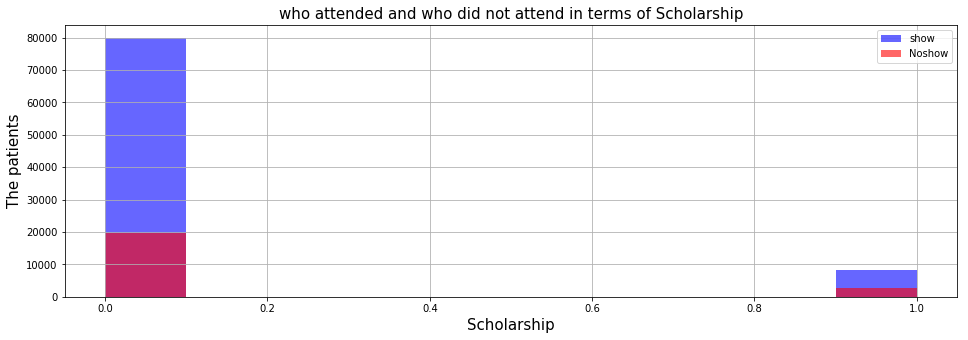

```python
# Does Scholarship affect the attendance rate
plt.figure(figsize=[16, 5])
df.Scholarship[SHOW].hist(alpha=0.6, color='blue', label='show')
df.Scholarship[NO_SHOW].hist(alpha=0.6, color='red', label='Noshow');
plt.title('who attended and who did not attend in terms of Scholarship', size=15)
plt.xlabel('Scholarship',size=15)
plt.ylabel('The patients', size=15,)
plt.legend();
```

- There is no clear relationship Scholarship is Little

## Hypertension

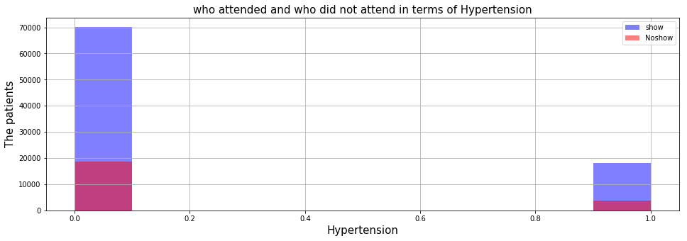

```python
# Does Hypertension affect the attendance rate
plt.figure(figsize=[16, 5])
df.Hypertension[SHOW].hist(alpha=0.5, color='blue', label='show')
df.Hypertension[NO_SHOW].hist(alpha=0.5, color='red', label='Noshow')
plt.title('who attended and who did not attend in terms of Hypertension', size=15)
plt.xlabel('Hypertension',size=15)
plt.ylabel('The patients', size=15,)
plt.legend();
```

- There is no clear relationship Hypertension is Little

## Diabetes

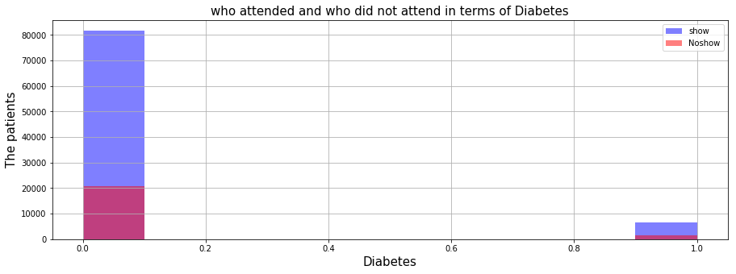

```python
# Does Diabetes affect the attendance rate
plt.figure(figsize=[15, 5])
df.Diabetes[SHOW].hist(alpha=0.5, color='blue', label='show')
df.Diabetes[NO_SHOW].hist(alpha=0.5, color='red', label='Noshow');
plt.title('who attended and who did not attend in terms of Diabetes', size=15)
plt.xlabel('Diabetes',size=15)
plt.ylabel('The patients', size=15,)
plt.legend();
```

- There is no clear relationship Diabetes is Little

## Alcoholism

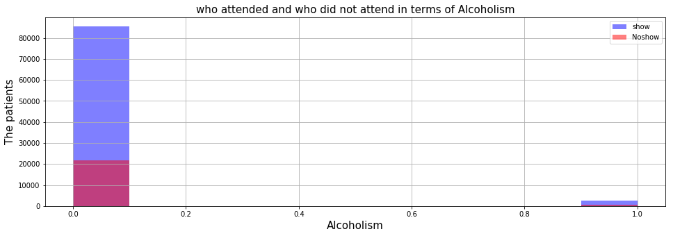

```python
# Does Alcoholism affect the attendance rate
plt.figure(figsize=[16, 5])
df.Alcoholism[SHOW].hist(alpha=0.5, color='blue', label='show')
df.Alcoholism[NO_SHOW].hist(alpha=0.5, color='red', label='Noshow')
plt.title('who attended and who did not attend in terms of Alcoholism', size=15)
plt.xlabel('Alcoholism',size=15)
plt.ylabel('The patients', size=15,)
plt.legend();
```

- There is no clear relationship Alcoholism is Little

## HANDCAP

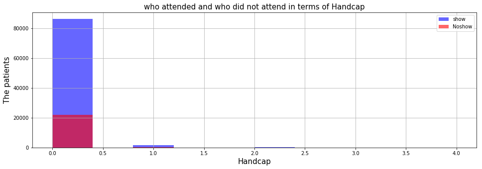

```python
# Does Handcap affect the attendance rate
plt.figure(figsize=[16, 5])
df.Handcap[SHOW].hist(alpha=0.6, color='blue', label='show')
df.Handcap[NO_SHOW].hist(alpha=0.6, color='red', label='Noshow')
plt.title('who attended and who did not attend in terms of Handcap', size=15)
plt.xlabel('Handcap',size=15)
plt.ylabel('The patients', size=15,)
plt.legend();
```

- There is no clear relationship Handcap is Little

## SMS RECEIVED

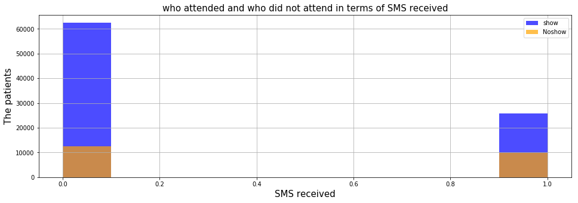

```python
# Does SMS received affect the attendance rate
plt.figure(figsize=[16, 5])
df.SMS_received[SHOW].hist(alpha=0.7, color='blue', label='show')
df.SMS_received[NO_SHOW].hist(alpha=0.7, color='orange', label='Noshow')
plt.title('who attended and who did not attend in terms of SMS received', size=15)
plt.xlabel('SMS received',size=15)
plt.ylabel('The patients', size=15,)
plt.legend();
```

- It seems to us that those who have received the messages are less present than those who have not

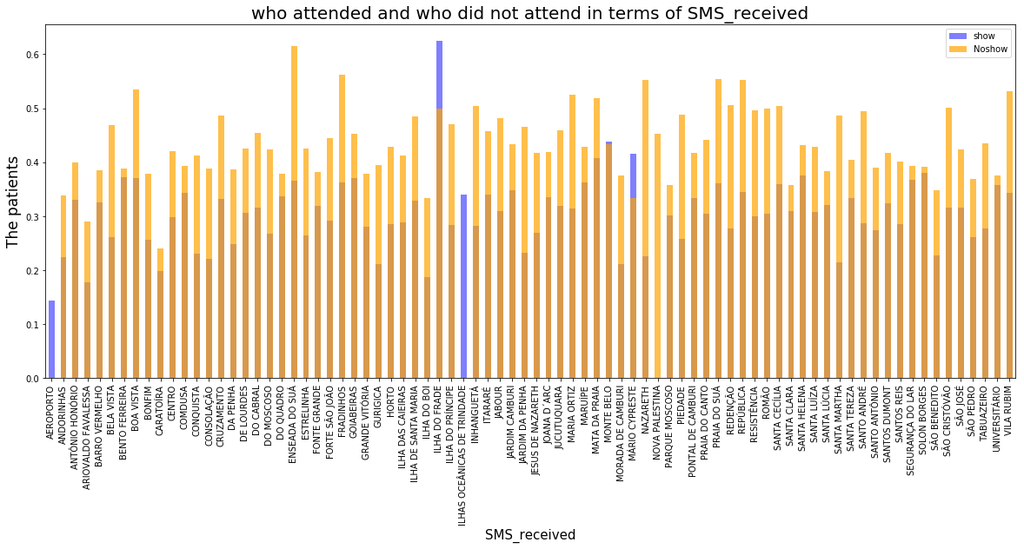

```python
# Are the received SMS messages sent differently from person to person?
plt.figure(figsize=[20, 7.5])
df[SHOW].groupby('Neighbourhood').SMS_received.mean().plot(kind='bar', alpha=0.5, color='blue', label='show')
df[NO_SHOW].groupby('Neighbourhood').SMS_received.mean().plot(kind='bar', alpha=0.7, color='orange', label='Noshow')
plt.title('who attended and who did not attend in terms of SMS_received', size=20)
plt.xlabel('SMS_received',size=15)
plt.ylabel('The patients', size=17,)
plt.legend();
```

- Only five neighborhoods responded to the letters
- This makes us want to know if the messages sent to all patients are the same

## NEIGHBOURHOOD

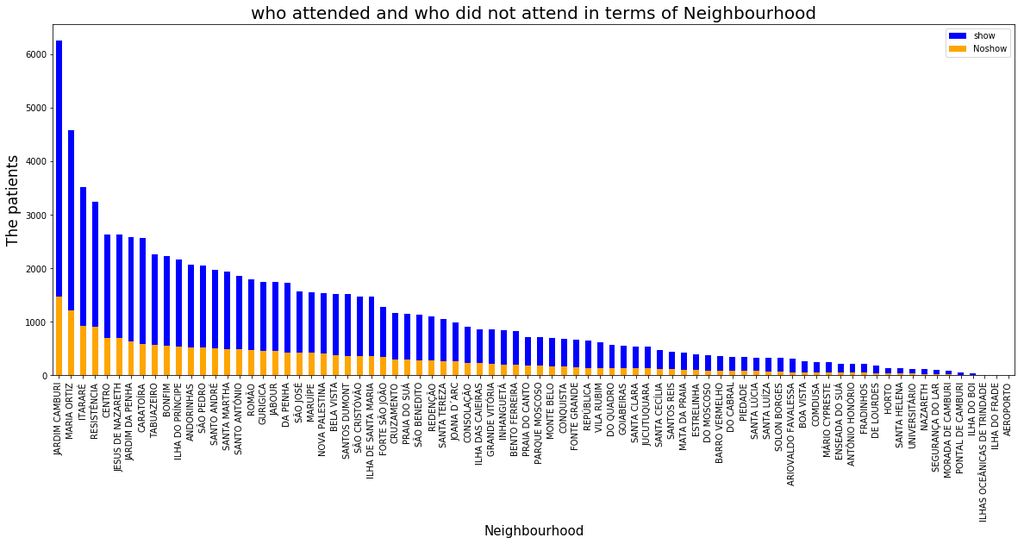

```python
# Does Neighbourhood affect the attendance rate
plt.figure(figsize=[20, 7.5])
df.Neighbourhood[SHOW].value_counts().plot(kind='bar' , color='blue', label='show')
df.Neighbourhood[NO_SHOW].value_counts().plot(kind='bar' , color='orange', label='Noshow')
plt.title('who attended and who did not attend in terms of Neighbourhood', size=20)
plt.xlabel('Neighbourhood',size=15)
plt.ylabel('The patients', size=17,)
plt.legend();
```

## Conclusions

### Limitations

- Other analyzes did not give a clear relationship

```python
from subprocess import call
call(['python', '-m', 'nbconvert', 'Investigate_a_Dataset.ipynb'])
```

```
0
```